# Zahra Pakzadnia

4001290473

```r
library(car)
data("Salaries")
my.id=73+20
```

(سوال اول)

```r
set.seed(my.id)
sample1=sample(Salaries$yrs.service,size = my.id);sample1
```

```
##  [1] 57 18 30 45 31  9 11  3 35  7 39 27  2 11 12 11 20  3 19 44 15  8 21 18  1
## [26] 12 16 18  0 20 44 39 25 44  4 36  3 28  8  9 20 21 38  6  6  4 11 23 31 36
## [51]  6 19 30  6 38 33 31 21  9  1 28 23 23  5  6  6 19  3 20 25 39  3 25 53 12
## [76]  4 26 33 35 18 17 14 19  0 26  1 15  2 27 19 20 37 18
```

میانگین

```r
set.seed(my.id)
mean(sample1)
```

```
## [1] 19.50538
```

میانه

```r
set.seed(my.id)
median(sample1)
```

```
## [1] 19
```

انحراف معیار

```r
set.seed(my.id)
sd(sample1)
```

```
## [1] 13.46947
```

واریانس

```r
set.seed(my.id)
var(sample1)
```

```
## [1] 181.4266
```

دامنه تغییرات

```r
set.seed(my.id)
range_value=max(sample1)-min(sample1);range_value
```

```
## [1] 57
```

چارک اول

```r
set.seed(my.id)
quantile(sample1,0.25)
```

```
## 25%
##   8
```

چارک دوم (میانه)

```r
set.seed(my.id)
quantile(sample1,0.5)
```

```
## 50%
##  19
```

چارک سوم

مقداری است که 75 درصد داده های یک مجموعه در سمت چپ آن (کمتر از آن) و 25 درصد در سمت راست آن (بیشتر از آن) قرار دارند

```r
set.seed(my.id)
quantile(sample1,0.75)
```

```
## 75%
##  28
```

رسم نمودار هسیتوگرام

```r
library(e1071)
```

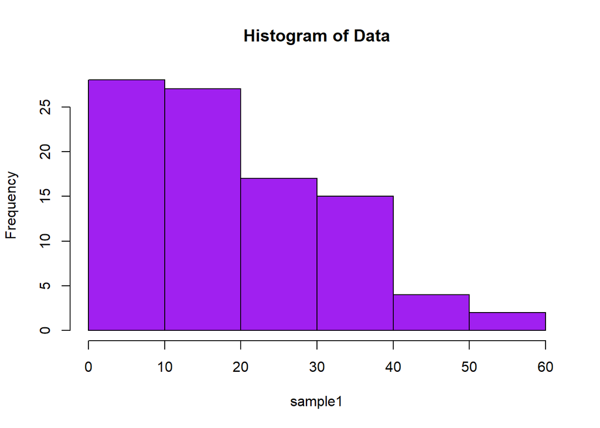

```r
set.seed(my.id)
hist(sample1,main="Histogram of Data",col="purple")
```

مقدار چولگی

در چولگی اگر مقدار مثبت باشد یعنی داده به سمت راست کشیده شده و اگر مقدار منفی باشد یعنی داده ها به سمت چپ کشیده شده اند

```r
set.seed(my.id)
skewness(sample1)
```

```
## [1] 0.5012493
```

مقدار کشیدگی

در کشیدگی اگر مقدار مثبت باشد به این معنی است که توزیع نوک تیز است و اگر مقدار منفی باشد توزیع پهن تر است

```r
set.seed(my.id)
kurtosis(sample1)
```

```
## [1] -0.493059
```

(سوال دوم)

از داده های کیفی گفته شده نمونه ای میگیریم و نمودار های مناسب را ترسیم می کنیم

```r
set.seed(my.id)
sample_rank=sample(Salaries$rank,size = my.id)
count_sample_rank=table(sample_rank)
```

رسم نمودار میله ای

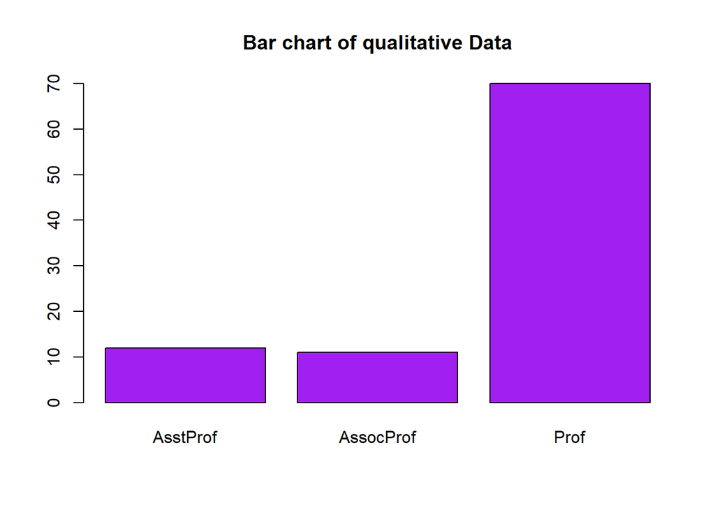

```r
barplot(count_sample_rank,main ="Bar chart of qualitative Data",col="purple")
```

رسم نمودار دایره ای

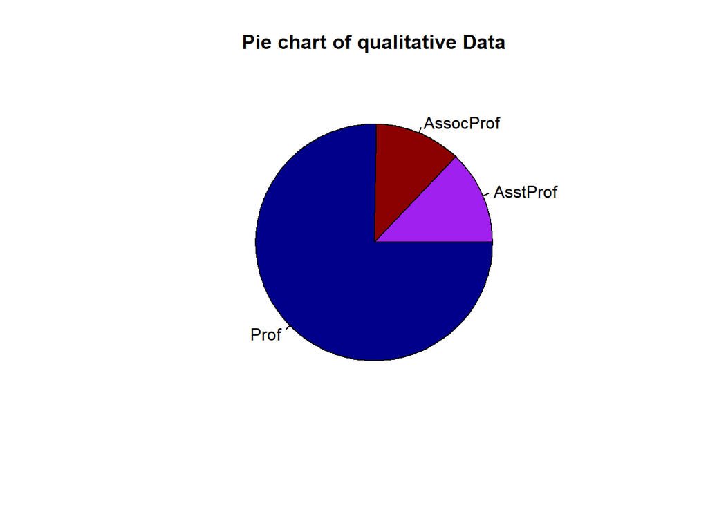

```r
pie(count_sample_rank,main ="Pie chart of qualitative Data",col=c("purple","darkred","darkblue"))
```

از داده های کمی گفته شده نمونه ای میگیریم و نمودار های مناسب را ترسیم می کنیم

```r
set.seed(my.id)
sample_salary=sample(Salaries$salary,size = my.id)
```

رسم نمودار هسیتوگرام

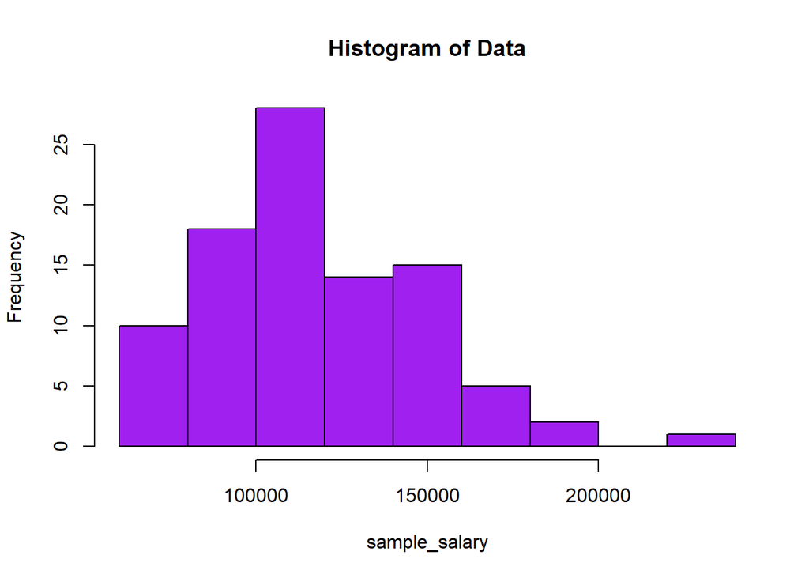

```r
set.seed(my.id)
hist(sample_salary,main ="Histogram of Data",col="purple")
```

رسم نمودار جعبه ای

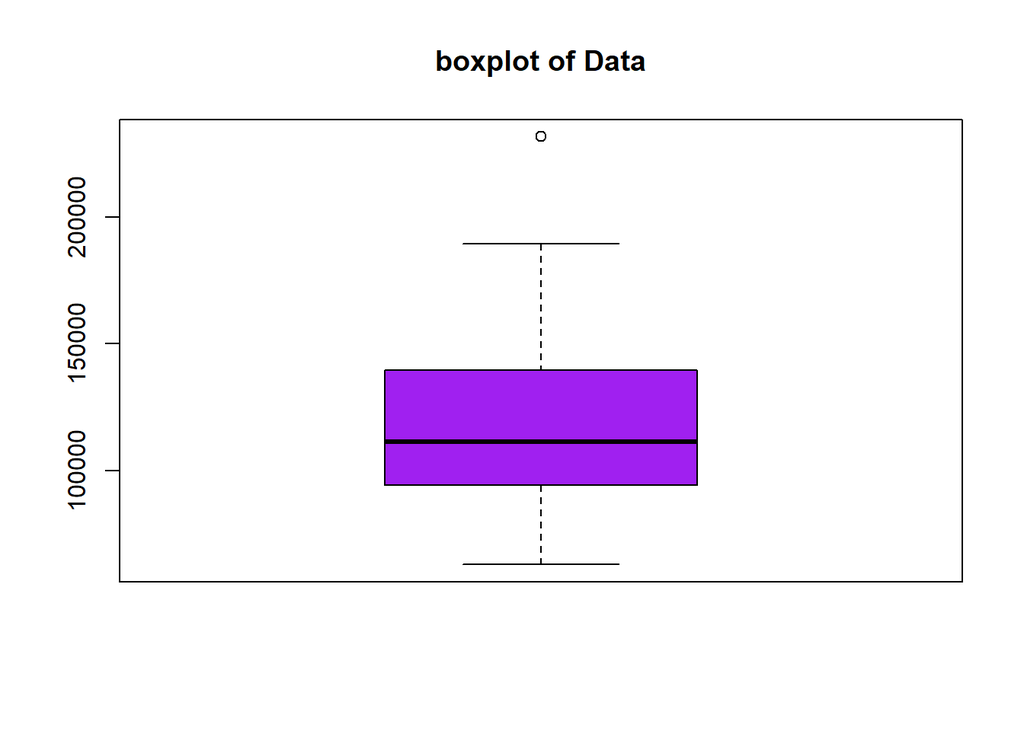

```r
set.seed(my.id)
boxplot(sample_salary,main ="boxplot of Data",col="purple")
```

رسم نمودار چگالی

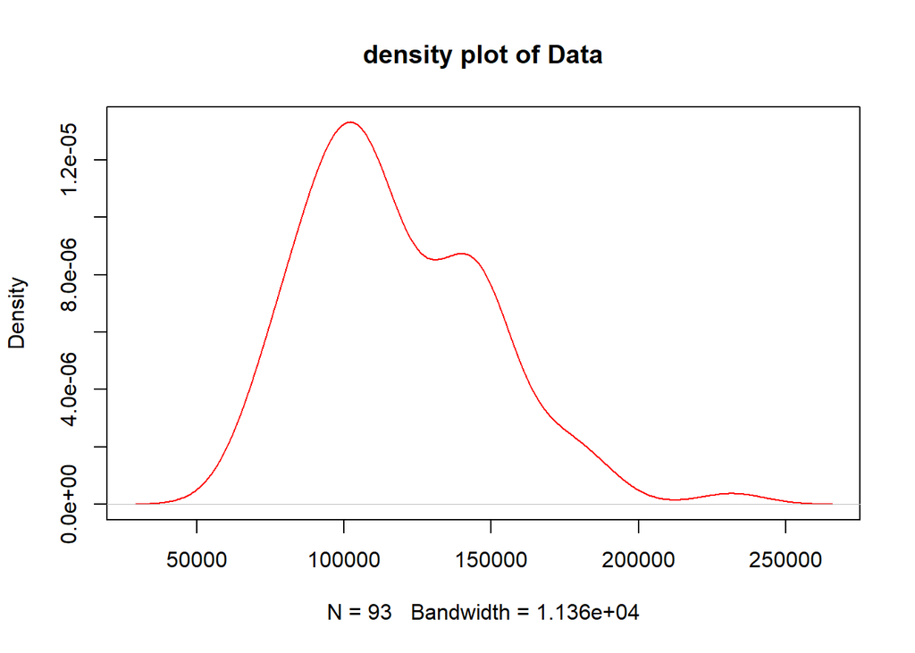

```r
set.seed(my.id)
plot(density(sample_salary),main ="density plot of Data",col="red")
```

(سوال سوم)

```r
set.seed(my.id)
random_normal_number=rnorm(100,50,10)
random_normal_number = round(random_normal_number);random_normal_number
```

```
##   [1] 47 43 57 59 58 38 77 60 59 59 54 37 68 55 58 45 54 56 61 34 39 47 51 49 52
##  [26] 49 50 47 57 40 60 45 47 40 63 49 60 69 45 53 64 50 57 60 44 50 67 71 66 45
##  [51] 52 40 49 32 44 59 58 38 49 50 63 45 53 42 63 38 36 60 47 60 38 45 56 66 55
##  [76] 35 58 55 56 47 70 48 64 57 35 59 48 44 26 46 45 58 56 42 46 49 55 46 55 48
```

تمامی اعداد بخش پذیر بر 6 در نمونه 100 تایی گرفته شده از توزیع نرمال

```r
set.seed(my.id)
multiple_6=sort(random_normal_number[random_normal_number%%6==0]);multiple_6
```

```
##  [1] 36 42 42 48 48 48 54 54 60 60 60 60 60 60 66 66
```

(سوال چهارم)

```r
set.seed(my.id)
x= Salaries$salary
n=length(x)

sum_denominator=function(x) {
  return(sum(1 / x))
}

denominator = sum_denominator(x)
Fx=n/denominator;Fx
```

```
## [1] 106305.6
```

(سوال پنجم)

انتگرال یگانه

```r
set.seed(my.id)

f <- function(x) {
  return(1+(x^2))
}

integral_1=integrate(f,0.5,3);integral_1
```

```
## 11.45833 with absolute error < 1.3e-13
```

محاسبه انتگرال با استفاده از بسته

انتگرال دوگانه

```r
library(pracma)
set.seed(my.id)

f <- function(x,y) {
  return(x+(y^2)-1)
}

integral_2=integral2(f,3,5,0,1);integral_2$Q
```

```
## [1] 6.666667
```

(سوال ششم)

```r
set.seed(my.id)
matrix_A = matrix(c(1,6,9,2,1,5,4,3,3),nrow=3,ncol=3);matrix_A
```

```
##      [,1] [,2] [,3]
## [1,]    1    2    4
## [2,]    6    1    3
## [3,]    9    5    3
```

دترمینان ماتریس

```r
set.seed(my.id)
det(matrix_A)
```

```
## [1] 90
```

معکوس ماتریس

```r
set.seed(my.id)
solve(matrix_A)
```

```
##            [,1]       [,2]        [,3]
## [1,] -0.1333333  0.1555556  0.02222222
## [2,]  0.1000000 -0.3666667  0.23333333
## [3,]  0.2333333  0.1444444 -0.12222222
```

صفر شدن قطر اصلی در ماتریس مورد نظر

```r
set.seed(my.id)
diag(matrix_A)=0;matrix_A
```

```
##      [,1] [,2] [,3]
## [1,]    0    2    4
## [2,]    6    0    3
## [3,]    9    5    0
```